# Reproducible Research: Peer Assessment 1

Work by mvelascoc (2014/08/10), avaliable in https://github.com/mvelascoc/RepData_PeerAssessment1

## Loading and preprocessing the data

```r
  ## Read de complete file
  file <- "activity.csv"
  data <- read.csv(file, header = TRUE)
  ## ignore incomplete data
  good <- complete.cases(data[,1])
  subdata <- data[good,]
  ## use date as factor to separate the data. This creates a list in which
    ## data from each day is separated
  stepsByDay <- split(subdata, subdata$date)
```

## What is mean total number of steps taken per day?

Data to be processed is the sum of the recorded steps each day. I create a table with this data. Note that the NA values were taken before calculating values requieres, but the days with 0 values were not. **I do not consider 0 to be a missing value** in this exercise: person could be asleep all day or in bed, I have no information to decide its wrong data. I am only taking away NA values.

```r
  ## Calculate the steps recorded per day by adding the steps recorded in each
    ## interval of the day, and save it in one single vector
  totalSteps <- data.frame(names(stepsByDay), 0)
  colnames(totalSteps) <- c("Day", "Total Steps Recorded")
  for (i in 1:length(stepsByDay)) {
      dimDay <- dim(stepsByDay[[i]])
      if (dimDay[1] > 0) {
         totalStepsDay <- sum(stepsByDay[[i]][,1])
         totalSteps[i,2] <- totalStepsDay
      }
  }
```

Data prepared is shown below:

```
##           Day Total Steps Recorded
## 1  2012-10-01                    0
## 2  2012-10-02                  126
## 3  2012-10-03                11352
## 4  2012-10-04                12116
## 5  2012-10-05                13294
## 6  2012-10-06                15420
## 7  2012-10-07                11015
## 8  2012-10-08                    0
## 9  2012-10-09                12811
## 10 2012-10-10                 9900
## 11 2012-10-11                10304
## 12 2012-10-12                17382
## 13 2012-10-13                12426
## 14 2012-10-14                15098
```

[output cut: 47 more lines]

Now, I calculate the descriptive statistics required.

```r
## Calculating mean and Median
  meanSteps <- mean(totalSteps[,2])
  medianSteps <- median(totalSteps[,2])
```

The mean total number of steps taken per day is `meanSteps` and median in `medianSteps`. Its values are shown:

```r
  print(paste ("Mean (value of meanSteps): ", meanSteps))
```

```
## [1] "Mean (value of meanSteps):  9354.22950819672"
```

```r
  print(paste ("Median (value of medianSteps): ", medianSteps))
```

```
## [1] "Median (value of medianSteps):  10395"
```

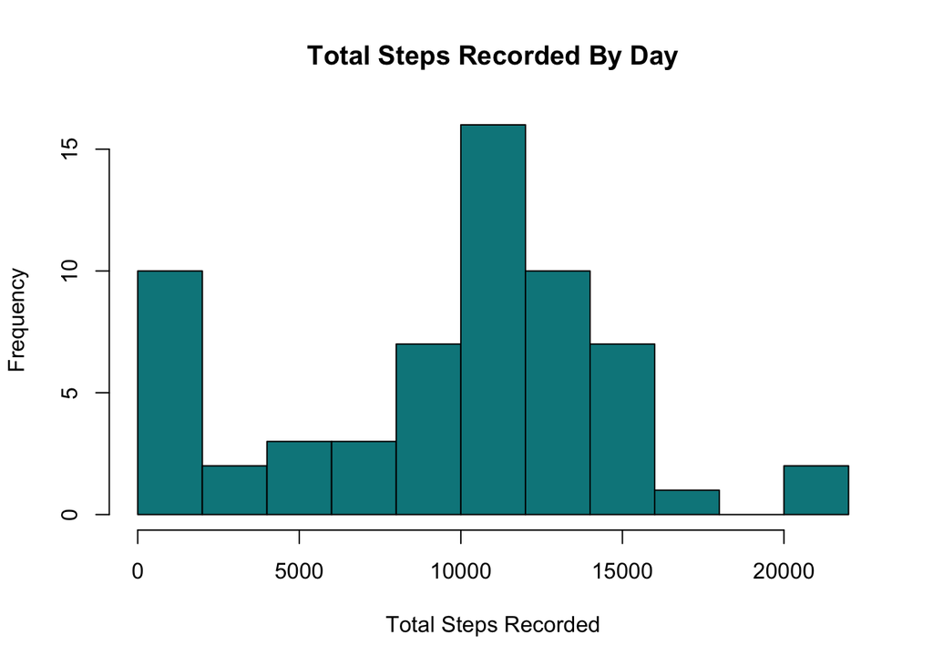

```r
  hist(totalSteps[,2], main = "Total Steps Recorded By Day",
       xlab = "Total Steps Recorded", col = "turquoise4", breaks = 10)
```

## What is the average daily activity pattern?

Daily activity required is the average for each interval. I will again use the prepared list `stepsByDay` that contains activity for each day to create a table.

Again, please note that I am not considering the values 0 as missing values.

```r
  ## take steps from one of the samples
  intFac <- factor(stepsByDay[[2]][,3], ordered = TRUE)
  interv <- levels(intFac)
  meanStepsByRange <- data.frame(interv, 0, 0)
  colnames(meanStepsByRange) <- c("Range",
                                  "Sum Total Steps Recorded", "Average Steps")
  for (i in 1:length(stepsByDay)) {  ##  for all days
      dimDay <- dim(stepsByDay[[i]])
      if (dimDay[1] > 0) {  ## if there is data in this day
         dimDay[1]
         for (j in 1: dimDay[1]) {  ## for all ranges
            range <-  stepsByDay[[i]][j,3]
            steps <- stepsByDay[[i]][j,1]
            meanStepsByRange[meanStepsByRange$Range == range, 2] <- meanStepsByRange[meanStepsByRange$Range == range, 2] + steps    ## I add the steps
         }

      }
  }
  ## when the adding is over, the average for all days is calculated
  meanStepsByRange[,3] <- meanStepsByRange[,2] / length(stepsByDay)
```

The average pattern for the steps is shown in the following graph

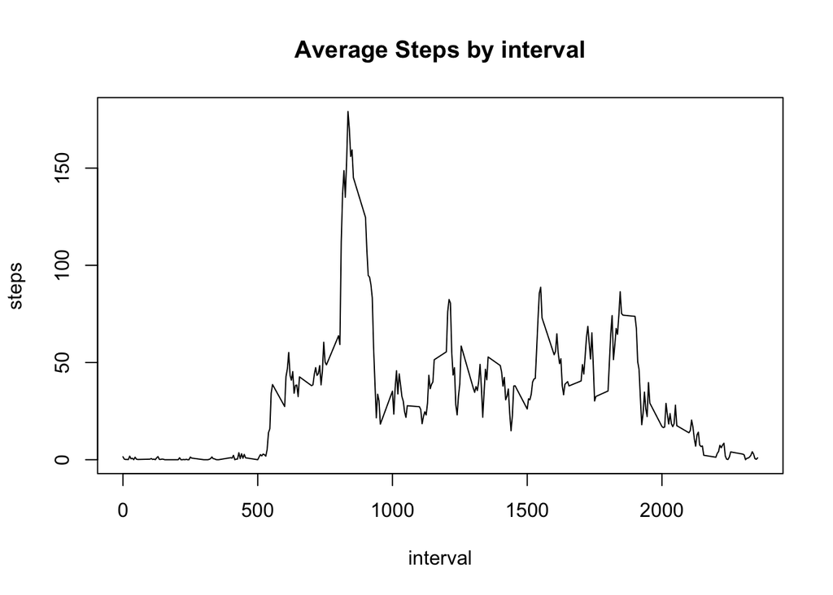

```r
  ## pattern is now shown in a graph
  plot(interv, meanStepsByRange[,3], type = "l",
       main = "Average Steps by interval", xlab = "interval", ylab = "steps")
```

The interval in which the average is the maximum is calculated and printed with

```r
    maxSteps <- max(meanStepsByRange[,3])
    index <- which(meanStepsByRange[,3] == maxSteps, arr.ind=TRUE)
    text <- paste("Maximum value is ", maxSteps,
                  " and its found in the interval ", meanStepsByRange[index,1])
   print(text)
```

```
## [1] "Maximum value is  179.131147540984  and its found in the interval  835"
```

## Imputing missing values

Since NA values were taken from the initial sample, vector `good` contains values that need to be replaced. I will create a new set of data incluing the mean value for the interval, rounded to next integer, calculated in the last section of the exercise.

```r
    ## calculate and print number of NA values
    goodValues <- as.numeric(!good)
    totalNAs <- sum(goodValues)
    text <- paste ("Number of NA data fields is ", totalNAs)
    print(text)
```

```
## [1] "Number of NA data fields is  2304"
```

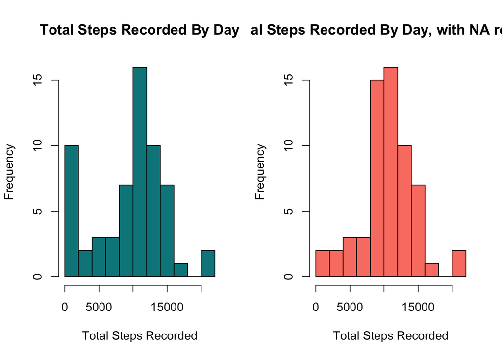

```r
    ## create a new vector in which NA data is replaced by average in the
    ## same interval
    dataWithNA <- data
    for (k in 1:dim(data)[1]){
        if (!(good[k])){  ## has a NA value
            index <- which(meanStepsByRange[,1] == data[k,3], arr.ind=TRUE)
            dataWithNA[k,1] <- round(meanStepsByRange[index,3])
        }
    }

  ## use date as factor to separate the data. This creates a list in which
    ## data from each day is separated, so processing is easier
  stepsByDayWithNA <- split(dataWithNA, dataWithNA$date)

    ## Now I repeat the same processing to get a histogram
## Calculate the steps recorded per day by adding the steps recorded in each
    ## interval of the day, and save it in one single vector
  totalSteps2 <- data.frame(names(stepsByDayWithNA), 0)
  colnames(totalSteps2) <- c("Day", "Total Steps Recorded")
  for (i in 1:length(stepsByDayWithNA)) {
      dimDay2 <- dim(stepsByDayWithNA[[i]])
      if (dimDay2[1] > 0) {
         totalStepsDay2 <- sum(stepsByDayWithNA[[i]][,1])
         totalSteps2[i,2] <- totalStepsDay2
      }
  }

  meanSteps2 <- mean(totalSteps2[,2])
  medianSteps2 <- median(totalSteps2[,2])


  par(mfrow = c(1,2))

  hist(totalSteps[,2], main = "Total Steps Recorded By Day",
       xlab = "Total Steps Recorded", col = "turquoise4", breaks = 10)

  hist(totalSteps2[,2], main = "Total Steps Recorded By Day, with NA replaced",
       xlab = "Total Steps Recorded", col = "salmon", breaks = 10)
```

```r
  print(paste ("Mean was: ", meanSteps, " and now its ", meanSteps2))
```

```
## [1] "Mean was:  9354.22950819672  and now its  10580.7213114754"
```

```r
  print(paste ("Median was: ", medianSteps, " and now its" ,medianSteps2))
```

```
## [1] "Median was:  10395  and now its 10395"
```

## Are there differences in activity patterns between weekdays and weekends?

To answer this question I am using the code used to plot the pattern, whith a change to separete weekdays from weekends.

```r
  ## take steps from one of the samples
  intFac2 <- factor(stepsByDay[[2]][,3], ordered = TRUE)
  interv2 <- levels(intFac2)
  meanStepsByRange2 <- data.frame(interv2, 0, 0, 0, 0)
  colnames(meanStepsByRange2) <- c("Range",  "Sum_Steps_Recorded_W", "Average_Steps_W", "Sum_Steps_Recorded_WEND", "Average_Steps_WEND")

  weekDaysNum <- 0   # counters of types of days, to be used to evaluate average
  weekendDaysNum <- 0
  Sys.setlocale("LC_TIME", "en_US") #make sure I can compare weekday names
```

```
## [1] "en_US"
```

```r
  for (i in 1:length(stepsByDay)) {  ##  for all days
      dimDay <- dim(stepsByDay[[i]])
      if (dimDay[1] > 0) {  ## if there is data in this day

         for (j in 1: dimDay[1]) {  ## for all ranges
             day <- strptime(stepsByDay[[i]][j,2], "%Y-%m-%d")
             dayName <- strftime(day, "%a")
             range <-  stepsByDay[[i]][j,3]
             steps <- stepsByDay[[i]][j,1]

             if (is.element( dayName, c("Sun","Sat"))) { #its a day of weekend
                weekendDaysNum <- weekendDaysNum + 1
               meanStepsByRange2[meanStepsByRange2$Range == range, 4] <- meanStepsByRange2[meanStepsByRange2$Range == range, 4] + steps    ## I add the steps
            } else {  # its a weekday
                weekDaysNum <- weekDaysNum + 1
               meanStepsByRange2[meanStepsByRange2$Range == range, 2] <- meanStepsByRange2[meanStepsByRange2$Range == range, 2] + steps    ## I add the steps

            }

         }

      }
  }
  ## when the adding is over, the average for all days is calculated
  meanStepsByRange2[,5] <- meanStepsByRange2[,4] / weekendDaysNum
  meanStepsByRange2[,3] <- meanStepsByRange2[,2] / weekDaysNum
```

The average pattern for the steps for Weekdays and Weekend days is shown in the following graph

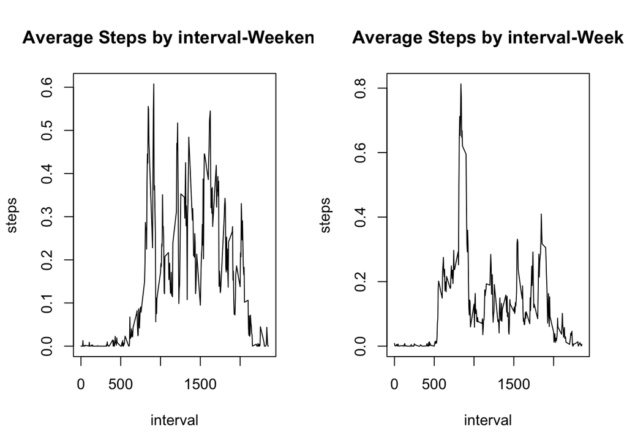

```r
  ## pattern is now shown in a graph
    par(mfrow = c(1,2))
    plot(interv2, meanStepsByRange2[,5], type = "l",
    main = "Average Steps by interval-Weekend", xlab = "interval", ylab = "steps")
    plot(interv2, meanStepsByRange2[,3], type = "l",
    main = "Average Steps by interval-Week", xlab = "interval", ylab = "steps")
```

In order to compare them easily, the averages are plotted togheter and a predictor is included

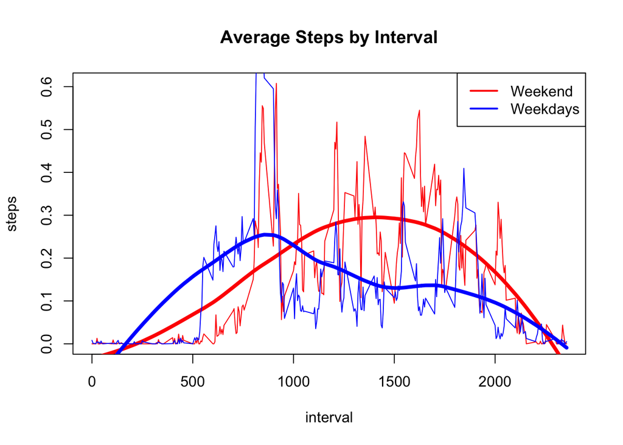

```r
    loWEND <- loess(meanStepsByRange2[,5]~interv2)
    loW <- loess(meanStepsByRange2[,3]~interv2)

    plot(interv2, meanStepsByRange2[,5], type = "l", col='red',
    main = "Average Steps by Interval", xlab = "interval", ylab = "steps")

    lines(interv2, predict(loWEND), col='red', lwd=4, type="l")
    lines(interv2, predict(loW), col='blue', lwd=4, type="l")
    lines(interv2, meanStepsByRange2[,3], type= "l", col="blue")

    legend(x="topright", legend=c("Weekend", "Weekdays"), lwd=2,
             col=c("red", "blue"))
```